# Optical Character Recognition

## Thuso Simon

- ## Why do we need OCR for identity documents
- ## Off the shelf OCR
- ## Character classification as OCR
- ## CTC and beam search
- ## Robust OCR
- ## Network architecture
- ## Results
- ## Future work

# Zoona

- Over the counter money transfers

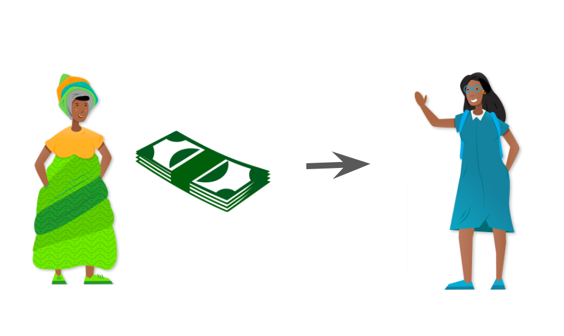

```python
Image('Images/send_cash.png')
```

[figure not shown]

```python
Image('Images/OTC.png')
```

# Zoona

- Anti-money laundering legislation
- Know your Consumer (KYC)
- These laws require us to correctly identify our consumers with some sort of valid Id
- Process is manual and takes a significant portion of time and is prone to mistakes

# Automatic KYC Using OCR

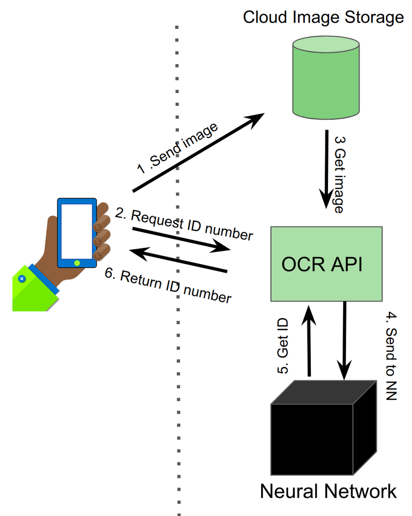

```python
Image('Images/end2end.png',retina=True)
```

# Lack of Data

- Launched mobile app recently
- Captured very few ID documents
- App was had bugs, so image quality was poor

# Zambian Identities

1. Identify consumer
2. Verify Know You Consumer (KYC)

[figure not shown]

```python
Image('Images/nrc.jpg')
```

## Naive OCR with Tesseract

```
Tessoract finds:
 "ﬂ. Ea?
{waaﬁ A

Q _

a"
```

[figure not shown]

```python
print('Tessoract finds: \n "{}"'.format(text))
Image(filename)
```

## Rotate a bit

```
Tessoract finds:
 ""
```

[figure not shown]

```python
print('Tessoract finds: \n "{}"'.format(text))
Image(filename_rot)
```

# Select only Registration Number region

```
Tessoract finds:
 ""
```

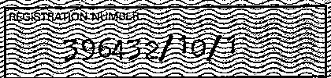

```python
print('Tessoract finds: \n "{}"'.format(text))
Image(filename_id_box)
```

# Small Data Plan

- Simulate text on the Zambia like ID
- Use transfer learning to make work with real ID's

# Simulation Example

```
Tessoract finds:
 ""
```

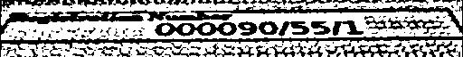

```python
# Simulated image
other_id = '../training_data/stage2/2_0.jpg'
other_img = ut.binarize_image(skimage.io.imread(other_id, as_grey=True))
filename_otherID = 'Images/otherID.jpeg'
skimage.io.imsave(filename_otherID,  255-255*other_img)
text = pytesseract.image_to_string(PIL.Image.open(filename_otherID))
#os.remove(filename)
print('Tessoract finds: \n "{}"'.format(text))
Image(filename_otherID)
```

# Evolution of OCR

## Character Classification

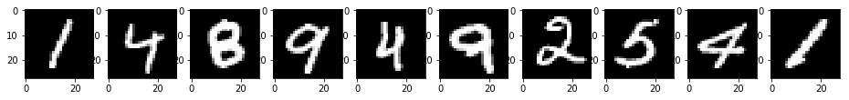

```python
# import mnist
from keras.datasets import mnist

(x_train, y_train), (x_test, y_test) = mnist.load_data()
shape = x_train.shape
# plot random numbers
fig, *ax = plt.subplots(1,10,figsize=(16,8))
for i_ax in ax[0]:
    i_ax.imshow(x_train[np.random.randint(0,shape[0])],cmap='gray')
```

# Train a model to recognize characters

- Add noise
- Add null class
- Rotation
- Off center image

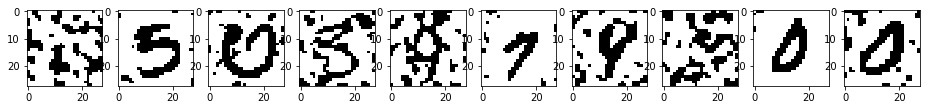

```python
# plot random numbers
fig, *ax = plt.subplots(1,10,figsize=(16,8))
for i_ax in ax[0]:
    i_ax.imshow(x_train[np.random.randint(shape[0]),:,:,0],cmap='gray')
```

# Network Architecture

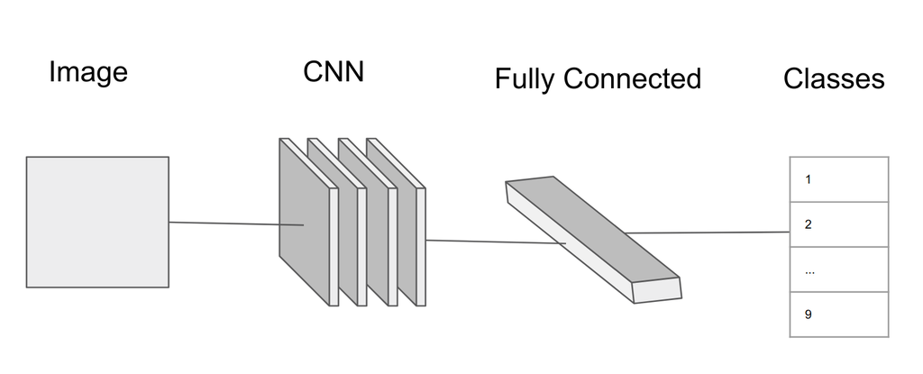

```python
Image('Images/mnist_NN.png')
```

```python
# Fist model
'''model.fit(x_train, y_train,
          batch_size=batch_size,
          epochs=epochs,
          verbose=1,
          validation_data=(x_test, y_test))'''
# save model
#model.save_weights('models/mnist.h5')
model.load_weights('models/mnist.h5')
score = model.evaluate(x_test, y_test, verbose=0)
print('Test loss: {:2.3f}'.format(score[0]))
print('Test accuracy: {:2.2f}'.format(score[1]))
```

```
Test loss: 0.075
Test accuracy: 0.98
```

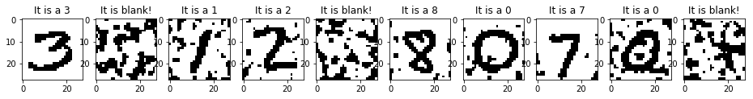

```python
# do classficication with trained model
#(x_train, y_train), (x_test, y_test) = mnist.load_data()
shape = x_test.shape
# plot random numbers
fig, *ax = plt.subplots(1,10,figsize=(16,20))
predict = model.predict_classes(x_test)

for i_ax in ax[0]:
    ind = np.random.randint(0,shape[0])
    img = x_test[ind]
    i_ax.imshow(img[:,:,0],cmap='gray')
    if predict[ind] == 10:
        smt = 'It is blank!'
    else:
        smt = 'It is a {}'.format(predict[ind])
    i_ax.set_title(smt)
```

## Sliding window OCR?

[video not shown]

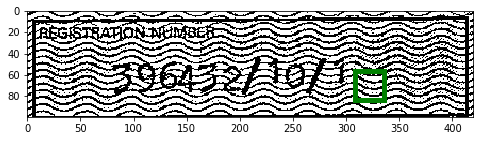

```python
# animation function. This is called sequentially
animate = ut.An(1-gray[60:160,260:680].astype(float)/255)
fig, ax = animate.init()
#fig, ax = plt.subplots(figsize=(8,4))
line = ax.imshow(1-gray[60:160,260:680].astype(float)/255, cmap='gray')

# call the animator. blit=True means only re-draw the parts that have changed.
anim = animation.FuncAnimation(fig, animate,
                               frames=100, interval=100, blit=True)
HTML(anim.to_html5_video())
```

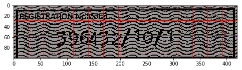

```python
# plot probablity over image
animate = ut.An(gray[60:160,260:680].astype(float)/255)
fig, ax = animate.init()
cmap = plt.get_cmap('hot')
ax.imshow(1-gray[60:160,260:680], cmap='gray')
for x,y,window in animate.window_gen:
    if window.shape[0] == animate.window_size[0] and window.shape[1] == animate.window_size[1]:
        if K.image_data_format() == 'channels_first':
            w = window.reshape(1, 1, 28, 28)
        else:
            w = window.reshape(1, 28, 28, 1)
        a = 1- model.predict_proba(w)[0,10]
    else:
        a = 0.
    ax.add_patch(plt.Rectangle((x, y),animate.window_size[0],animate.window_size[1],
                               fill=True,alpha=.4,fc=cmap(a) ,ec='red'))
```

# Problems

- Deal with misalignment of numbers
- Deal with spaces
- Character data sets like MNIST don't have dashes
- Different sizes of images
- Better deal with noise
- Make OCR more robust

# Connectionist Temporal Classiﬁcation (CTC)

- Loss function to deal where you don't know where the characters will be in image
- Works well with RNN's
- CTC object for a single X,Y pair is:

$P(Y|X) = \sum_{All-Valid} \prod_{t=1}^{T} p_t(a_t|X)$

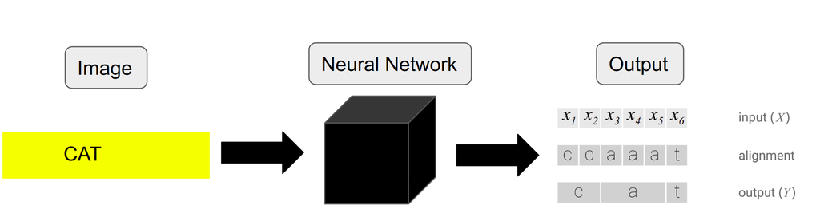

```python
Image('Images/ctc_introduction.png')
```

# Connectionist Temporal Classiﬁcation

- Need a way to deal with duplicate characters
- We introduce a null symbol $\epsilon$ to split characters or end words

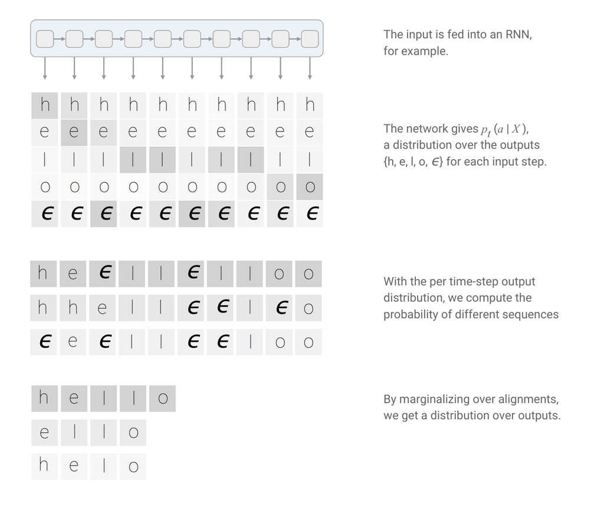

```python
Image('Images/marginal_ctc.png', retina=True)
```

# Decoding CTC Output

- Output of a CTC network is a probability matrix of classes

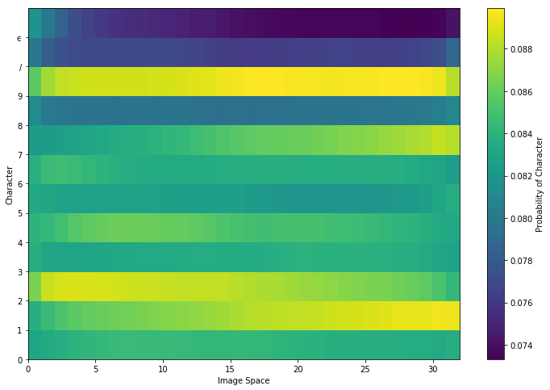

```python
Image('Images/CTCOutput_NRC.png')
```

## Valid alignments

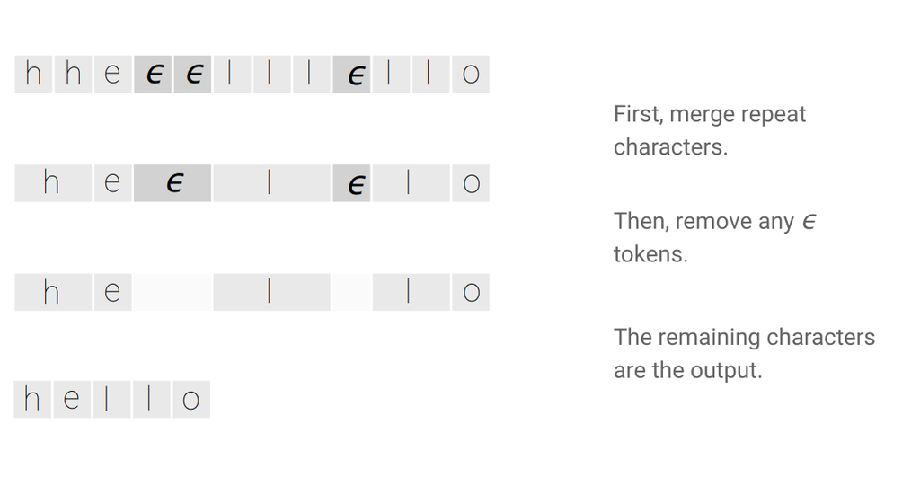

```python
Image('Images/recovering_input.png')
```

# Beam Search

- Want to find the most likely alignment path

$Y^* = argmax P(Y|X)$

- Simple approach is to take the maximum probability path
- There could be different paths that collapse into the same string and add up to be more than the max probability path

# Beam Search

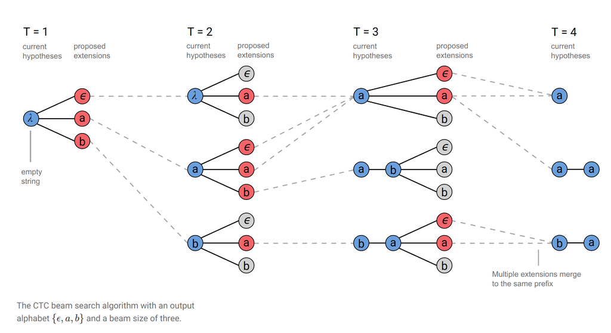

```python
Image('Images/beamsearch.png')
```

# OCR Revisited

- Want to use CTC to do OCR
- Like to have OCR deal with spacial structure of image
- Be general purpose to read all useful data from ID

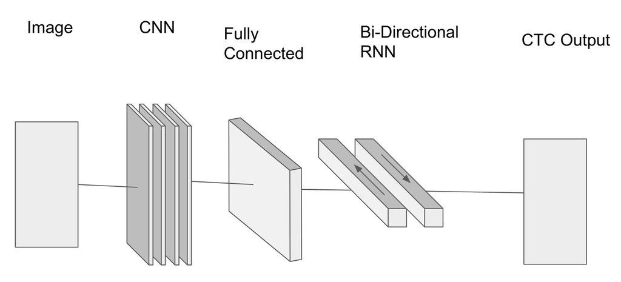

```python
Image('Images/ctcrnn.png')
```

# Building Network in Keras

- Keras allows for rapid prototyping of network architecture
- Keras isn't made for using loss functions like CTC so some hacks are needed
- Has flexibility of tensorflow so users can use state of art methods

## Deciding Network Architecture

- Read papers, look at other examples, talk to people
- Transfer learn if possible
- Prototyping networks require scaled down parameters so fitting is fast
- Network should be able to memorize subset of data
- Set up quick benchmarks to test different activations, number of neurons, and optimizers
- Be prepared that no of it will work (deep learning is still an art)

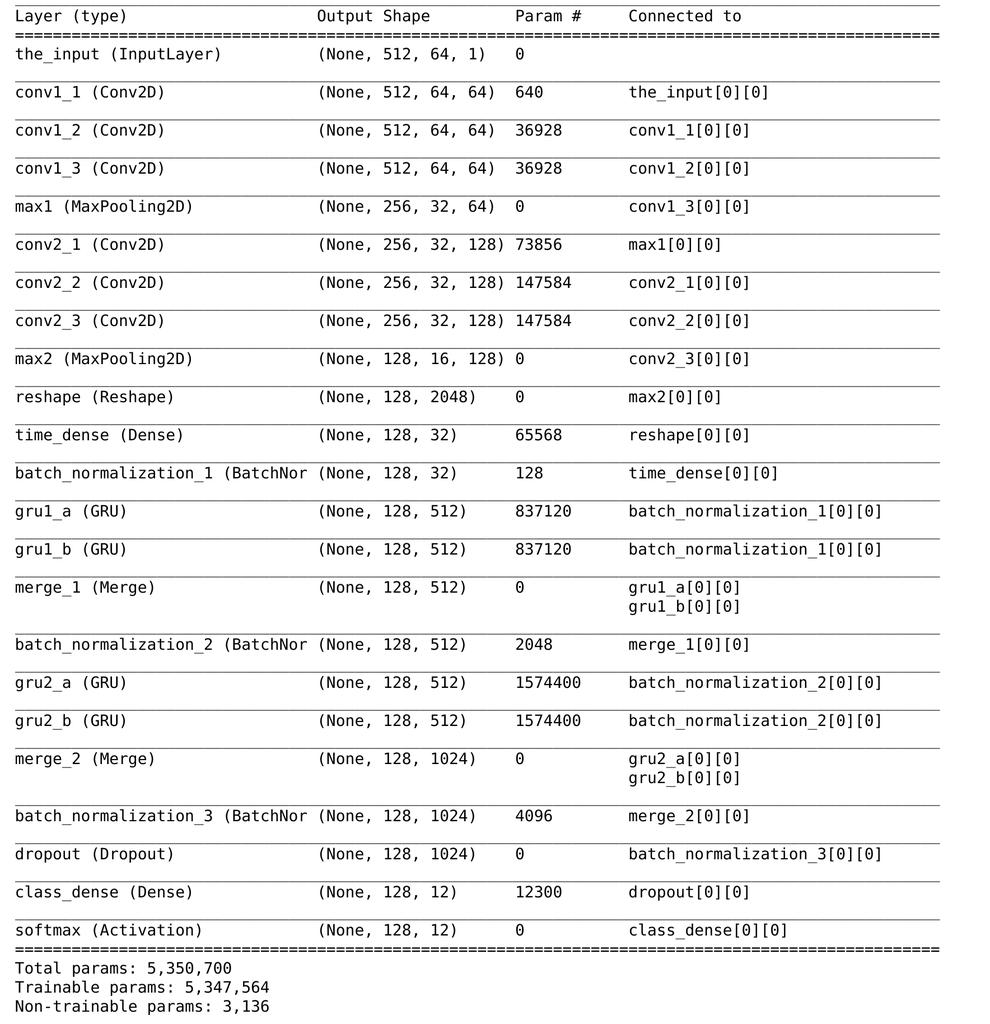

```python
Image('Images/OCR_structure.png', retina=True)
```

# Visualizing Layers

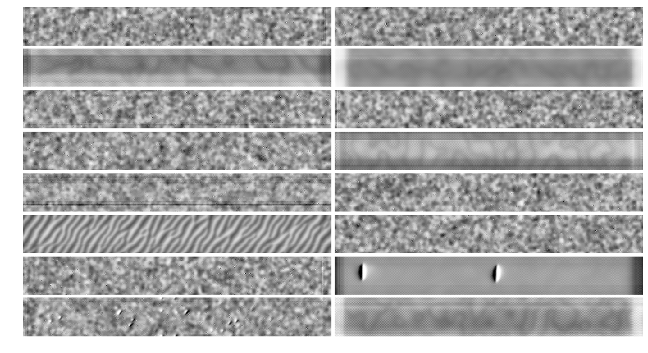

```python
Image('Images/cnn_vis.png')
```

# Results

```
CTC OCR finds "7 2 7 2 7 2 7 2 7 2 7 2 7 2 7 2 7 2 7 2 7 2 7 2 7 2 7 2 7 2 7 2 7 2 7 2 7 2 7 2 7 2 7 2 7 2 7 2 7 2 7"
```

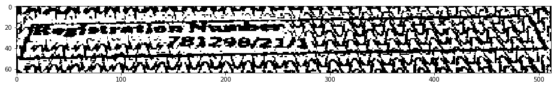

```python
# Plot image and correct text
fig, ax = plt.subplots(figsize=(16,8))
ax.imshow(img['the_input'][idx,:,:,0].T,cmap='gray')
print('CTC OCR finds "{}"'.format(' '.join(map(str, predicted_beam[idx]))))
```

# Real image

```
OCR finds "7 2 7 2 7 2 7 2 7 2 7 2 7 2 7 2 7 2 7 2 7 2 7 2 7 2 7 2 7 2 7 2 7 2 7 2 7 2 7 2 7 2 7 2 7 2 7 2 7 2 7"
```

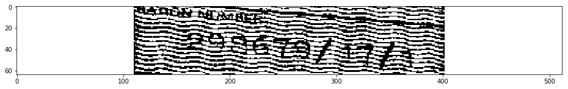

```python
fig, ax = plt.subplots(figsize=(16,8))
ax.imshow(r_img['the_input'][idx,:,:,0].T, cmap='gray')
print('OCR finds "{}"'.format(' '.join(map(str, predicted_beam[idx]))))
```

# Other Tips and Tricks

- Make models separate to notebooks
- Figure out what a good cost actually means
- If your model is unstable, try batch normalization

# Furture Work

- Text in the wild to extract text box automatically
- Image segmentation to extract text without background

# Meetups

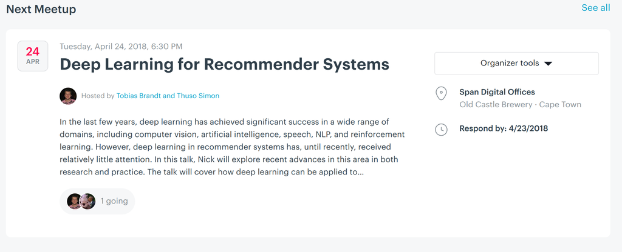

```python
Image('Images/meetups_talk.png')
```

- https://www.meetup.com/machinelearningcapetown/

# References/Questions?

- Most of the images come from https://distill.pub/2017/ctc/